# Day 6 - Data Visualization

Maggie L. Warren and Lucas A. Nell

2023-12-01

## Data Visualization packages to install

Install the GGally, ggpubr, and ggsignif packages

```r
install.packages(c("GGally", "ggpubr", "ggsignif",
                   "viridis", "scales", "viridisLite",
                   "survival", "survminer", "ggalluvial",
                   "stringr"))
library(GGally)
library(ggpubr)
library(ggsignif)
library(viridis)
library(scales)
library(viridisLite)
library(survival)
library(survminer)
library(ggalluvial)
library(stringr)
```

## Exploring the data

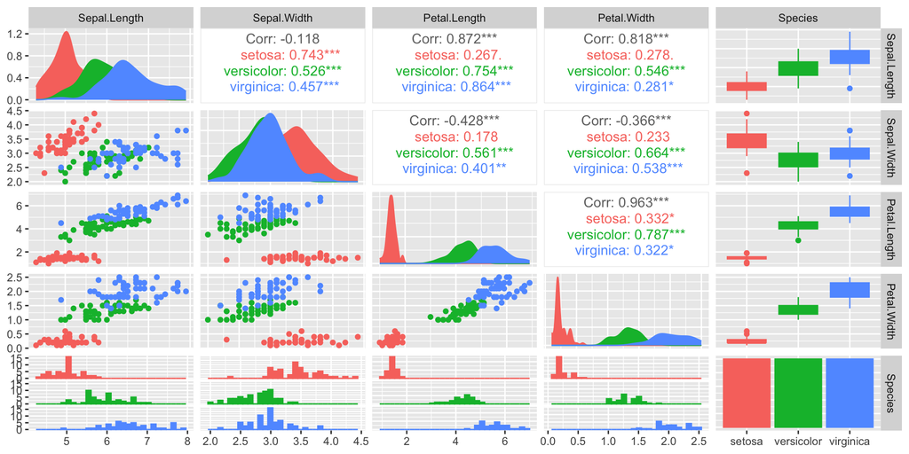

```r
ggpairs(iris, aes(color = Species, fill = Species), progress = F)
```

## Anatomy of a ggplot figure

```r
ggplot(data = <DATA>) +
  <GEOM_FUNCTION>(
     mapping = aes(<MAPPINGS>),
     stat = <STAT>,
     position = <POSITION>
  ) +
  <COORDINATE_FUNCTION> +
  <FACET_FUNCTION>
```

## Lets build a basic ggplot figure |Let’s use the iris dataset.

```r
head(iris)
```

```
  Sepal.Length Sepal.Width Petal.Length Petal.Width Species
1          5.1         3.5          1.4         0.2  setosa
2          4.9         3.0          1.4         0.2  setosa
3          4.7         3.2          1.3         0.2  setosa
4          4.6         3.1          1.5         0.2  setosa
5          5.0         3.6          1.4         0.2  setosa
6          5.4         3.9          1.7         0.4  setosa
```

## Lets build a basic ggplot figure | Now we can add the aesthetics.

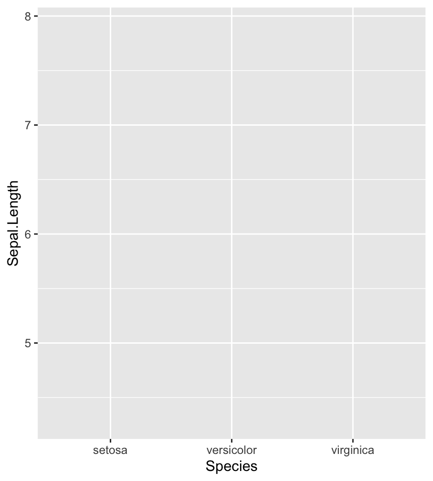

```r
iris |>
  ggplot(aes(x = Species, y = Sepal.Length))
```

## Lets build a basic ggplot figure | We can visualize the distribution with a violin plot

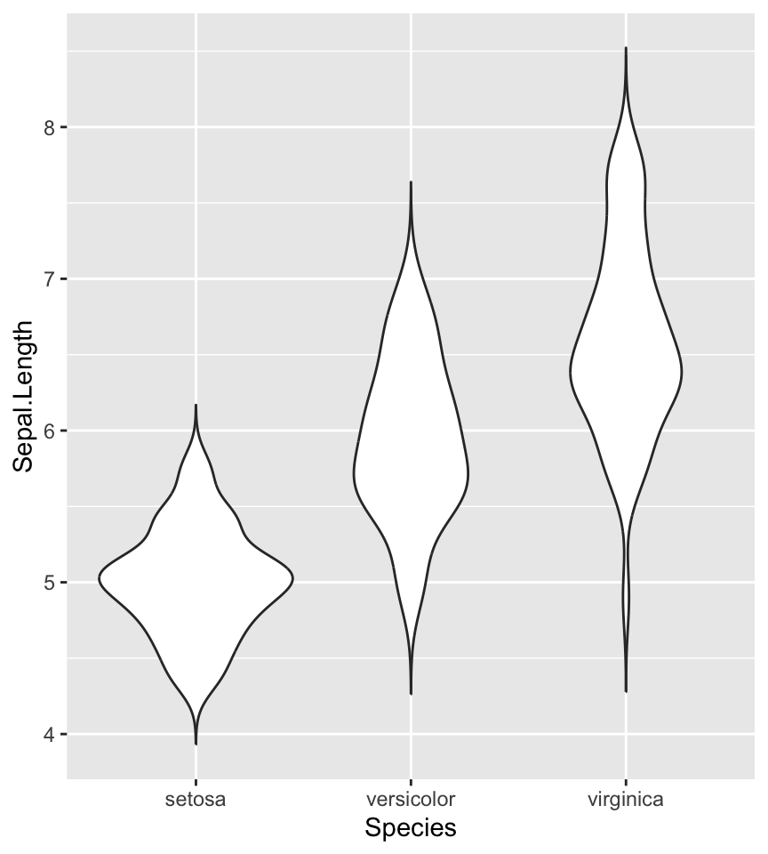

```r
iris |>
  ggplot(aes(x = Species, y = Sepal.Length)) +
  geom_violin(trim = FALSE)
```

## Lets build a basic ggplot figure | Lets add the data on top

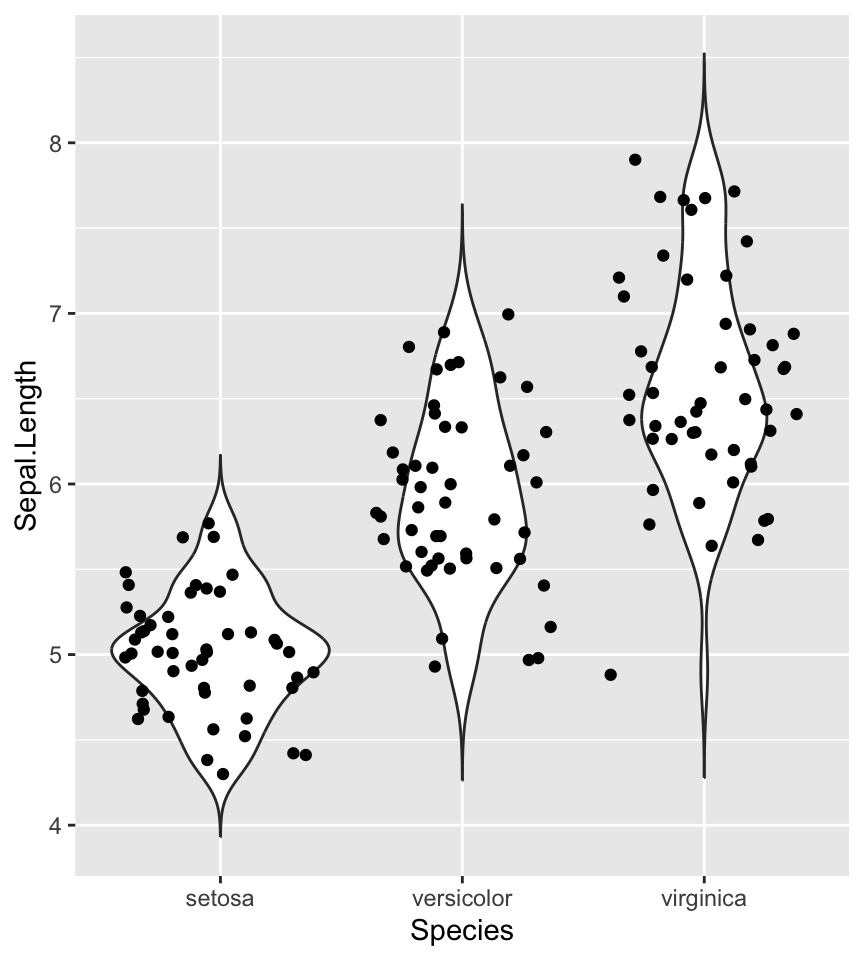

```r
iris |>
  ggplot(aes(x = Species, y = Sepal.Length)) +
  geom_violin(trim = FALSE) +
  geom_jitter()
```

## Lets build a basic ggplot figure | Add some statistics

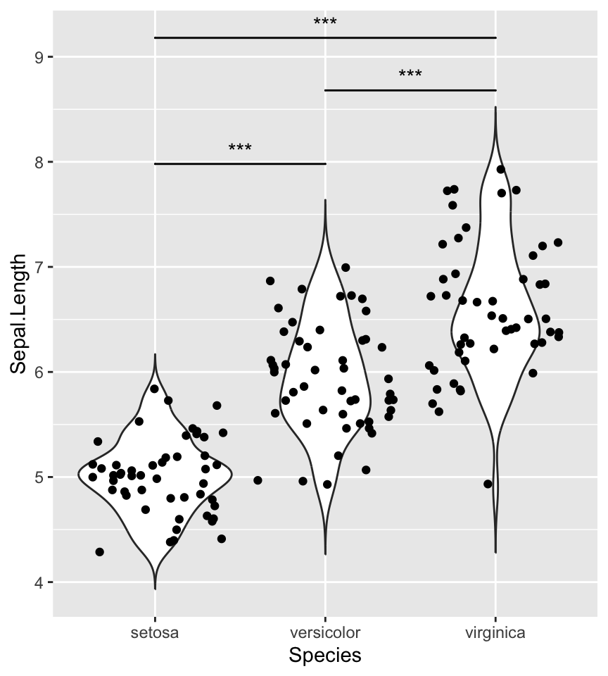

```r
iris |>
  ggplot(aes(x = Species, y = Sepal.Length)) +
  geom_violin(trim = FALSE) +
  geom_jitter() +
  geom_signif(comparisons =
                list(c("setosa", "versicolor"),
                     c("versicolor", "virginica"),
                     c("setosa", "virginica")),
              map_signif_level = T,
              y_position = c(7.8, 8.5, 9),
              tip_length = 0)
```

## Lets build a basic ggplot figure | Change the y label and add color to violin plot and data

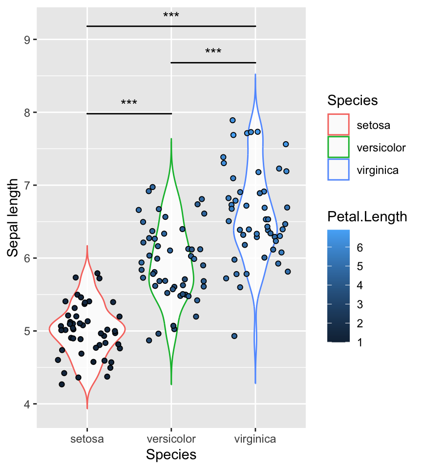

```r
iris |>
  ggplot(aes(x = Species, y = Sepal.Length)) +
  geom_violin(aes(color = Species), trim = FALSE, alpha = 0.8) +
  geom_jitter(aes(fill = Petal.Length), shape = 21) +
  geom_signif(comparisons =
                list(c("setosa", "versicolor"),
                     c("versicolor", "virginica"),
                     c("setosa", "virginica")),
              map_signif_level = T,
              y_position = c(7.8, 8.5, 9),
              tip_length = 0) +
  ylab("Sepal length")
```

## Lets build a basic ggplot figure | Now we’ll removed the violin plot legend, change the color palette, labels

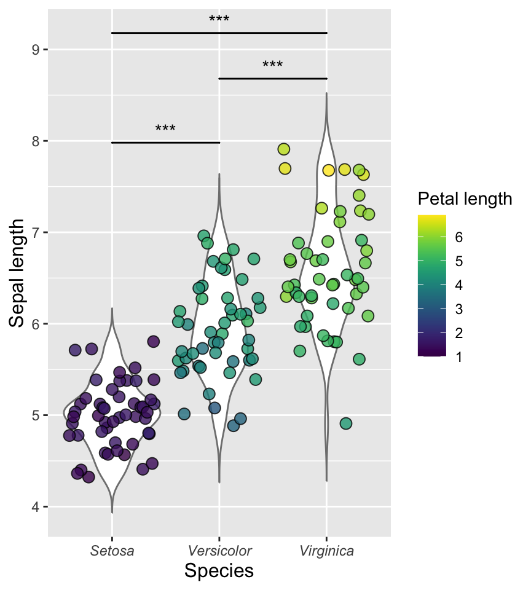

```r
iris |>
  mutate(Species = str_to_title(Species)) |>
  ggplot(aes(x = Species, y = Sepal.Length)) +
  geom_violin(aes(color = Species), trim = FALSE,
              show.legend = FALSE) +
  geom_jitter(aes(fill = Petal.Length), shape = 21, size = 3,
              alpha = 0.8) +
  geom_signif(comparisons =
                list(c("Setosa", "Versicolor"),
                     c("Versicolor", "Virginica"),
                     c("Setosa", "Virginica")),
              map_signif_level = T,
              y_position = c(7.8, 8.5, 9),
              tip_length = 0) +
  scale_fill_viridis(name = "Petal length") +
  scale_color_manual(values = c("setosa" = "#06d6a0",
                                "versicolor" = "#118ab2",
                                "virginica" = "#073b4c")) +
  ylab("Sepal length") +
  theme(axis.title = element_text(size = 12),
        axis.text.x = element_text(face = "italic"))
```

## Basic figures: Survival plotCode from https://rkabacoff.github.io/datavis/Models.html#survival-plots

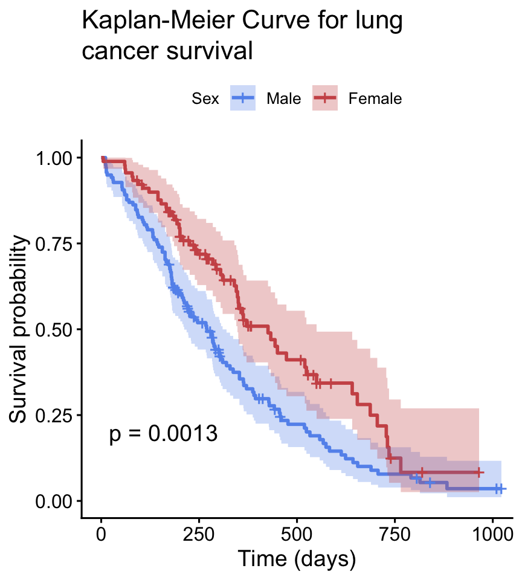

```r
data(lung)
sfit <- survfit(Surv(time, status) ~  sex, data=lung)
ggsurvplot(sfit,
           conf.int=TRUE,
           pval=TRUE,
           legend.labs=c("Male", "Female"),
           legend.title="Sex",
           palette=c("cornflowerblue", "indianred3"),
           title="Kaplan-Meier Curve for lung
           cancer survival",
           xlab = "Time (days)")
```

## Basic figures: Bubble chartCode from https://rkabacoff.github.io/datavis/Other.html#Bubble

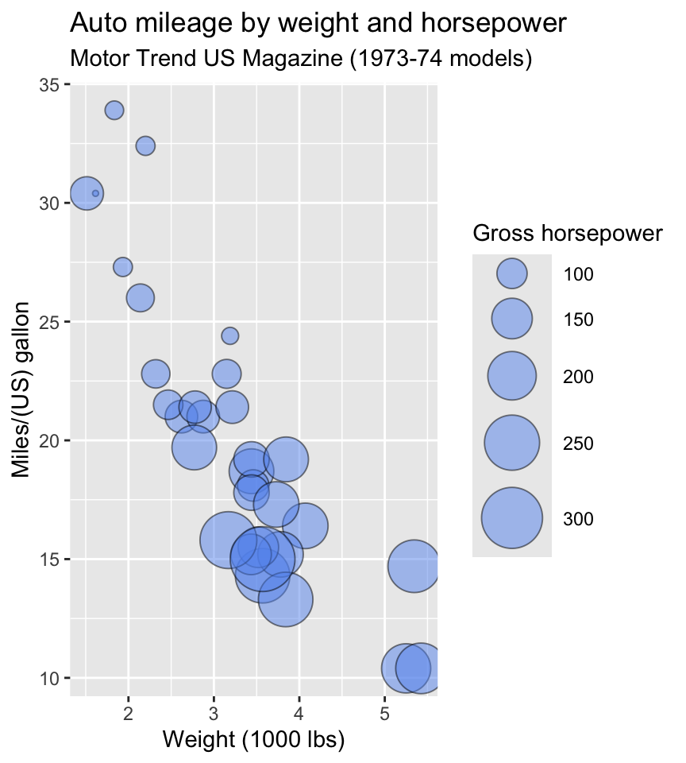

```r
ggplot(mtcars,
       aes(x = wt, y = mpg, size = hp)) +
  geom_point(alpha = .5,
             fill="cornflowerblue",
             color="black",
             shape=21) +
  scale_size_continuous(range = c(1, 14)) +
  labs(title = "Auto mileage by weight
       and horsepower",
       subtitle = "Motor Trend US Magazine
       (1973-74 models)",
       x = "Weight (1000 lbs)",
       y = "Miles/(US) gallon",
       size = "Gross horsepower")
```

## Basic figures: BiplotCode from https://rkabacoff.github.io/datavis/Other.html#biplots

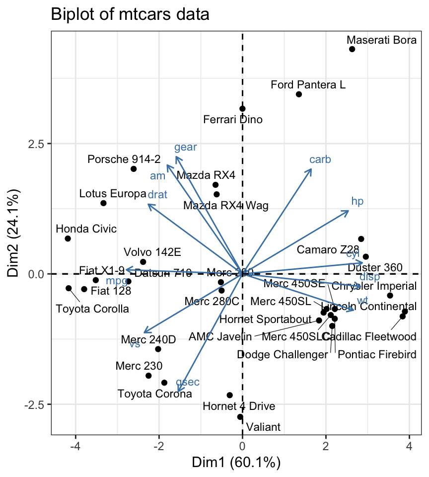

```r
# fit a principal components model
fit <- prcomp(x = mtcars,
              center = TRUE,
              scale = TRUE)

# plot the results
library(factoextra)
fviz_pca(fit,
         repel = TRUE,
         labelsize = 3) +
  theme_bw() +
  labs(title = "Biplot of mtcars data")
```

## Basic figures: Alluvial diagramsCode from https://rkabacoff.github.io/datavis/Other.html#alluvial-diagrams

```r
# Quick data wrangling
mtcars_table <- mtcars %>%
  mutate(am = factor(am, labels = c("Auto", "Man")),
         cyl = factor(cyl),
         gear = factor(gear),
         carb = factor(carb)) %>%
  group_by(cyl, gear, carb, am) %>%
  count()
```

## Basic figures: Alluvial diagramsCode from https://rkabacoff.github.io/datavis/Other.html#alluvial-diagrams

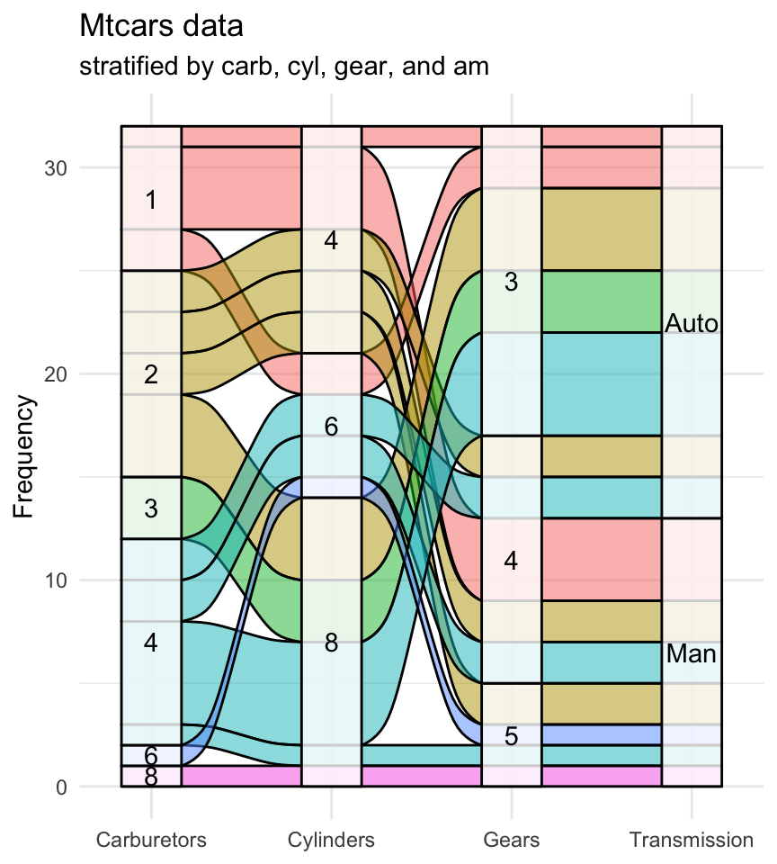

```r
ggplot(mtcars_table,
       aes(axis1 = carb,
           axis2 = cyl,
           axis3 = gear,
           axis4 = am,
           y = n)) +
  geom_alluvium(aes(fill = carb), color="black") +
  geom_stratum(alpha=.8) +
  geom_text(stat = "stratum",
            aes(label = after_stat(stratum))) +
  scale_x_discrete(limits =
                     c("Carburetors", "Cylinders",
                              "Gears", "Transmission"),
                   expand = c(.1, .1)) +
  # scale_fill_brewer(palette="Paired") +
  labs(title = "Mtcars data",
       subtitle = "stratified by carb, cyl,
       gear, and am",
       y = "Frequency") +
  theme_minimal() +
  theme(legend.position = "none")
```

## Basic figures: Sorted heat mapCode from https://rkabacoff.github.io/datavis/Other.html#heatmaps

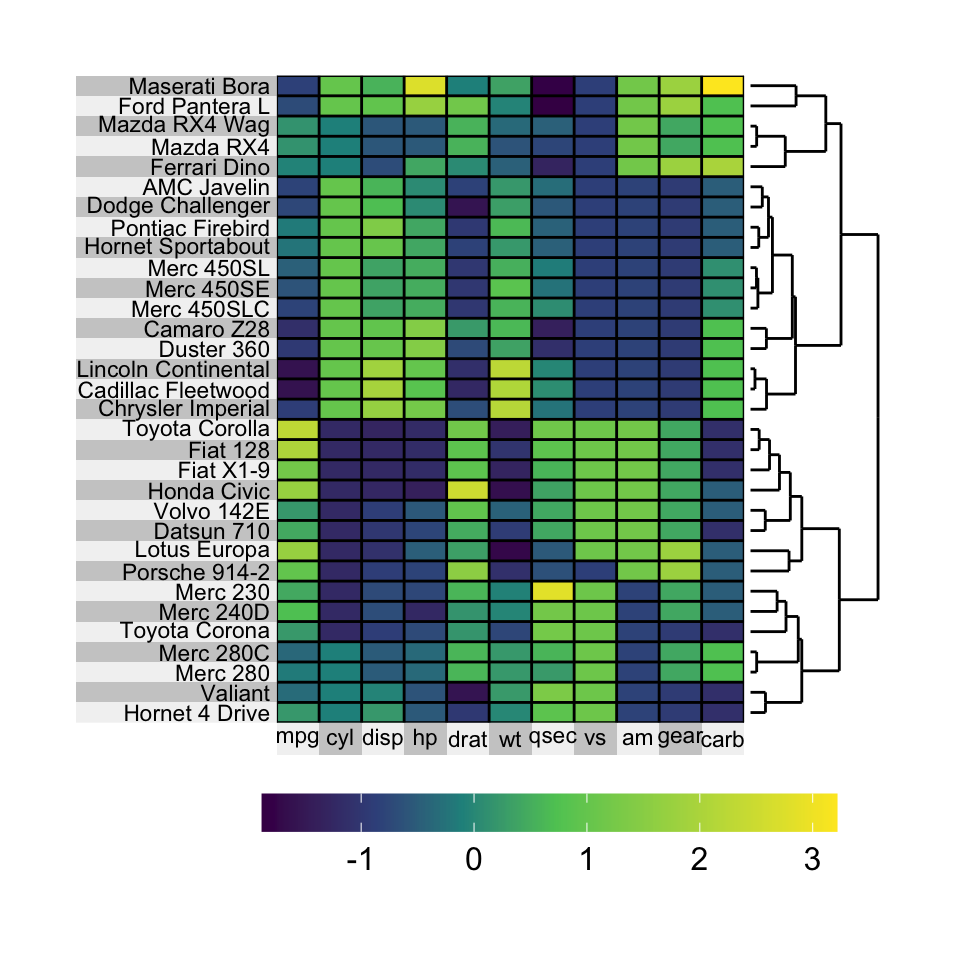

```r
library(superheat)
superheat(mtcars,
          scale = TRUE,
          left.label.text.size=3,
          bottom.label.text.size=3,
          bottom.label.size = .05,
          row.dendrogram = TRUE )
```

## Basic figures: Interactive mapsCode from https://rkabacoff.github.io/datavis/Maps.html#geocoding

[interactive chart not shown]

```r
library(ggmap)
library(mapview)
library(sf)

# subset the data
homicide <- filter(crime,
                   offense == "murder") %>%
  select(date, offense, address, lon, lat)
# view data
head(homicide, 3)
mymap <- st_as_sf(homicide, coords = c("lon", "lat"),
                  crs = 4326)
mapview(mymap)
```

## Basic figures: BarplotsCode from https://r4ds.had.co.nz/data-visualisation.html#the-layered-grammar-of-graphics

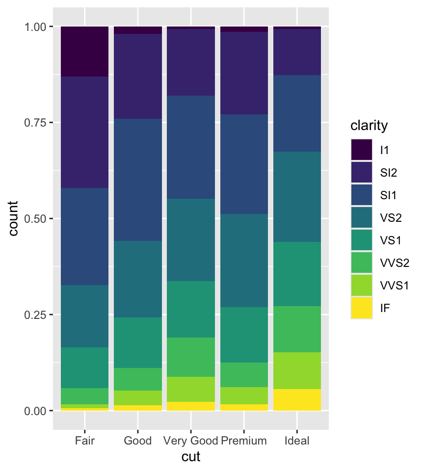

```r
ggplot(data = diamonds) +
  geom_bar(mapping = aes(x = cut, fill = clarity),
           position = "fill")
```

## Basic figures: BarplotsCode from https://r4ds.had.co.nz/data-visualisation.html#the-layered-grammar-of-graphics

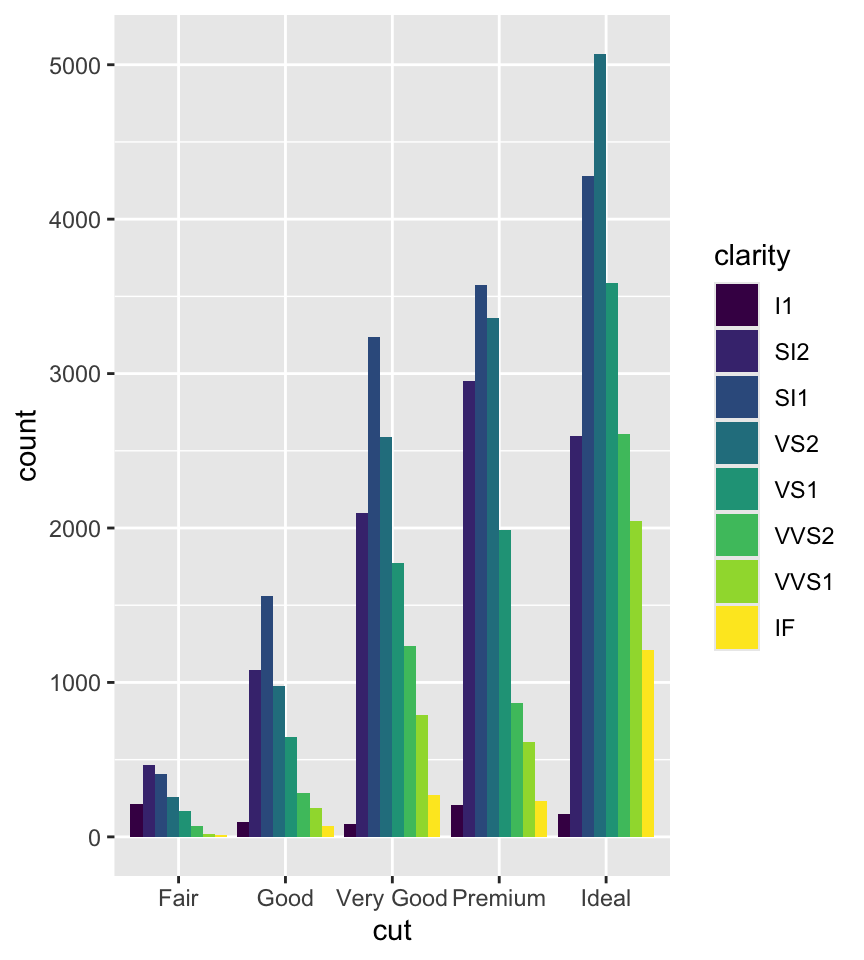

```r
ggplot(data = diamonds) +
  geom_bar(mapping = aes(x = cut, fill = clarity),
           position = "dodge")
```

## Basic figures: BoxplotsCode from http://www.sthda.com/english/articles/24-ggpubr-publication-ready-plots/#google_vignette

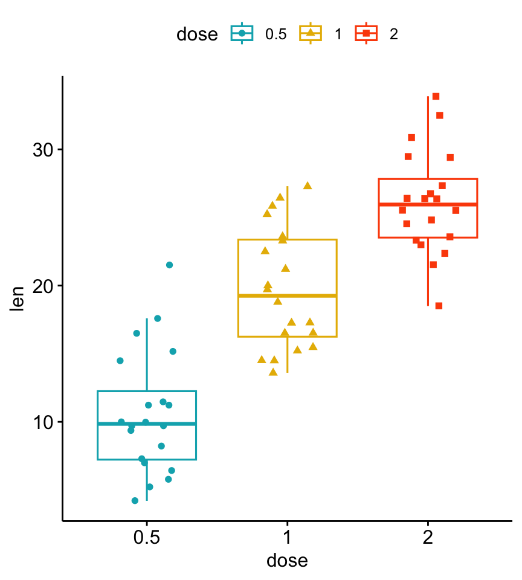

```r
p = ggboxplot(ToothGrowth, x = "dose", y = "len",
      color = "dose",
      palette =c("#00AFBB", "#E7B800", "#FC4E07"),
      add = "jitter", shape = "dose")
p
```

## Basic figures: BoxplotsCode from http://www.sthda.com/english/articles/24-ggpubr-publication-ready-plots/#google_vignette

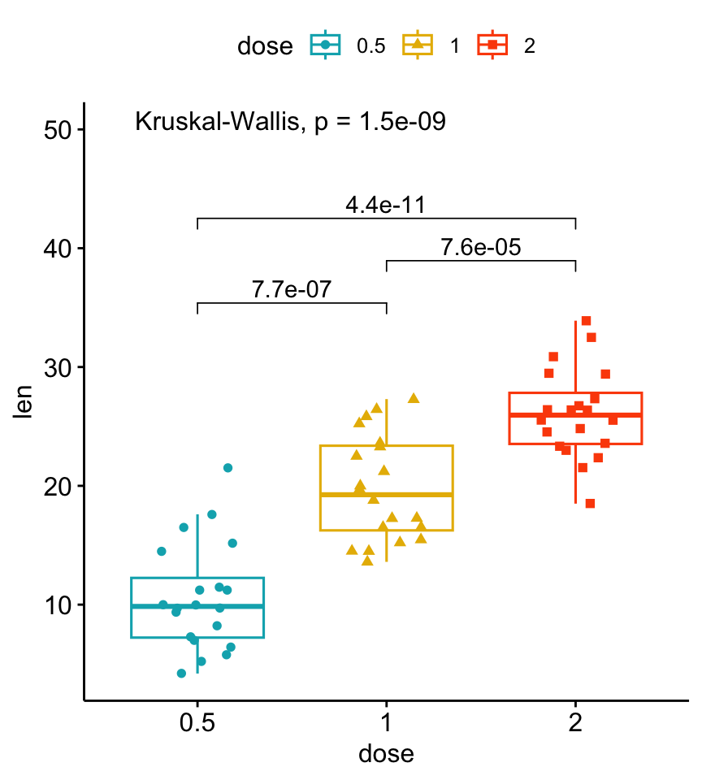

```r
# Add p-values comparing groups
 # Specify the comparisons you want
my_comparisons <- list( c("0.5", "1"),
                        c("1", "2"),
                        c("0.5", "2") )
# Add pairwise comparisons p-value
p + stat_compare_means(comparisons =
                         my_comparisons) +
  # Add global p-value
  stat_compare_means(label.y = 50)
```

## Basic figures: Violin plot with box plot insideCode from http://www.sthda.com/english/articles/24-ggpubr-publication-ready-plots/#google_vignette

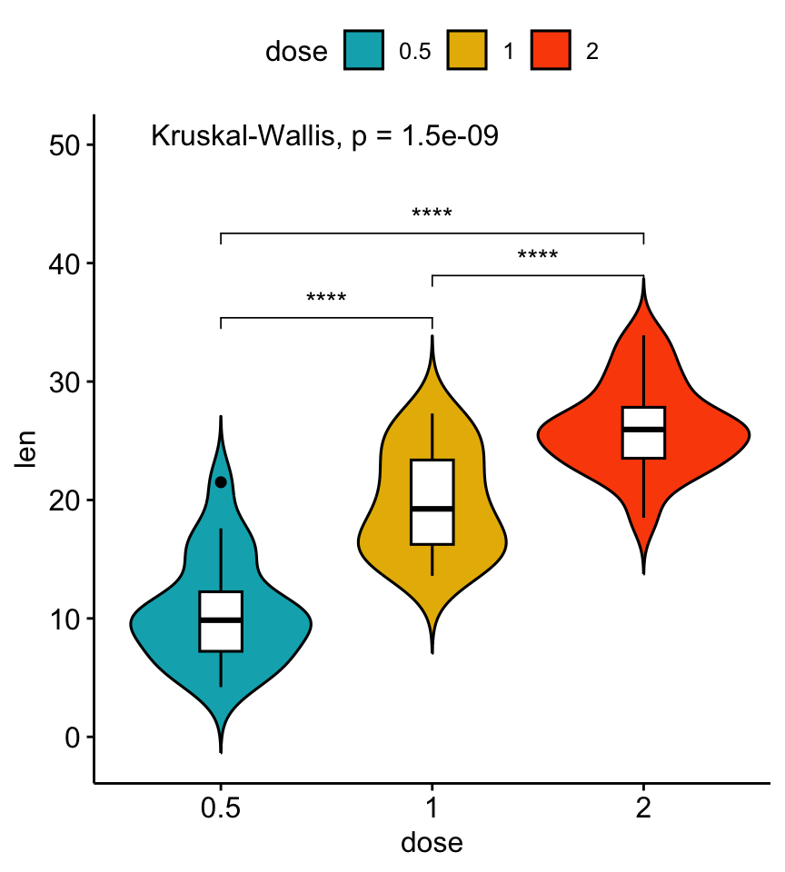

```r
ggviolin(ToothGrowth, x = "dose", y = "len",
         fill = "dose",
         palette = c("#00AFBB", "#E7B800", "#FC4E07"),
         add = "boxplot",
         add.params = list(fill = "white")) +
  # Add significance levels
  stat_compare_means(comparisons = my_comparisons,
                     label = "p.signif") +
  # Add global the p-value
  stat_compare_means(label.y = 50)
```

## Basic figures: Dot chartCode from http://www.sthda.com/english/articles/24-ggpubr-publication-ready-plots/#google_vignette

```r
dfm <- mtcars
# Some wrangling
dfm = dfm |>
        mutate(cyl = as.factor(cyl),
               mpg_z = (mpg - mean(mpg))/sd(mpg),
               mpg_grp = factor(ifelse(mpg_z < 0, "low", "high"),
                                levels = c("low", "high"))) |>
        rownames_to_column(var = "name")
# Convert the cyl variable to a factor
dfm$cyl <- as.factor(dfm$cyl)
# Add the name colums
dfm$name <- rownames(dfm)
# Calculate the z-score of the mpg data
dfm$mpg_z <- (dfm$mpg -mean(dfm$mpg))/sd(dfm$mpg)
dfm$mpg_grp <- factor(ifelse(dfm$mpg_z < 0, "low", "high"),
                     levels = c("low", "high"))
```

## Basic figures: Dot chartCode from http://www.sthda.com/english/articles/24-ggpubr-publication-ready-plots/#google_vignette

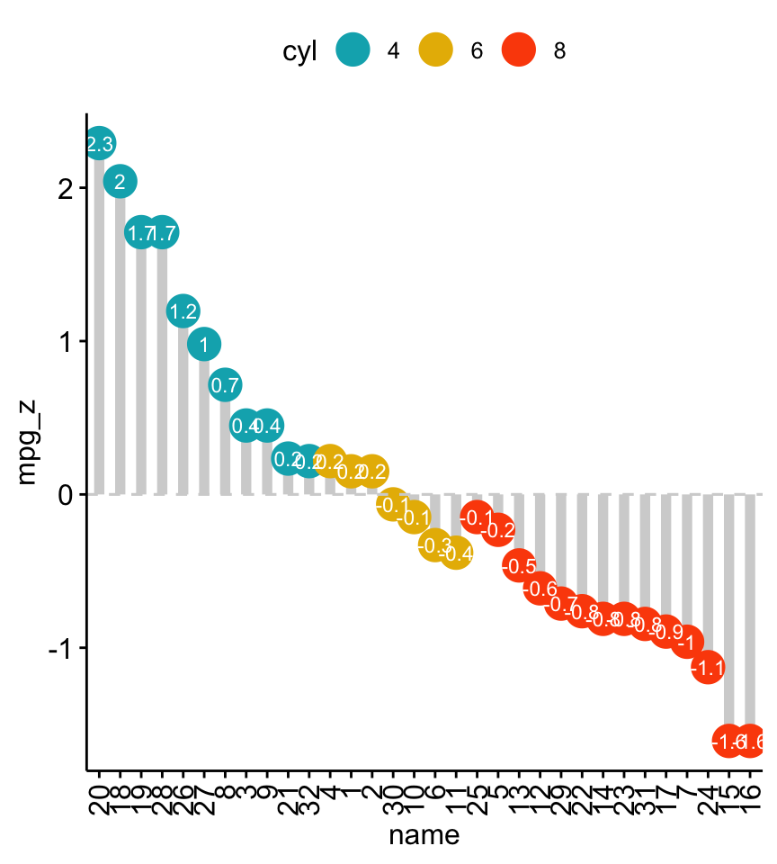

```r
ggdotchart(dfm, x = "name", y = "mpg_z",
           # Color by groups
           color = "cyl",
           # Custom color palette
           palette = c("#00AFBB", "#E7B800", "#FC4E07"),
           # Sort value in descending order
           sorting = "descending",
           # Add segments from y = 0 to dots
           add = "segments",
           # Change segment color and size
           add.params = list(color = "lightgray", size = 2),
            # Order by groups
           group = "cyl",
           # Large dot size
           dot.size = 6,
           # Add mpg values as dot labels
           label = round(dfm$mpg_z,1),
           # Adjust label parameters
           font.label = list(color = "white", size = 9,
                             vjust = 0.5),
           # ggplot2 theme
           ggtheme = theme_pubr()
           ) +
           geom_hline(yintercept = 0, linetype = 2,
                      color = "lightgray")
```

## Basic figures: Faceted plotCode from http://www.sthda.com/english/articles/24-ggpubr-publication-ready-plots/83-create-and-customize-multi-panel-ggplots-easy-guide-to-facet/

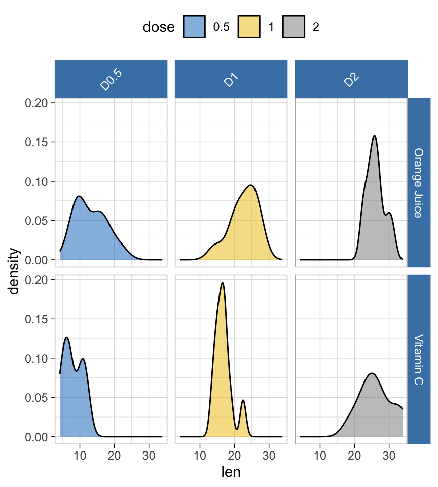

```r
df = ToothGrowth |>
  mutate(dose = as.factor(dose))
p <- ggdensity(df, x = "len", fill = "dose",
               palette = "jco",
               ggtheme = theme_light(),
               legend = "top")
facet(p, facet.by = c("supp", "dose"),
       panel.labs = list(
         supp = c("Orange Juice", "Vitamin C"),
         dose = c("D0.5", "D1", "D2")
         ),
       panel.labs.background = list(color = "steelblue",
                                    fill = "steelblue",
                                    size = 0.5),
       panel.labs.font = list(color = "white"),
       panel.labs.font.x = list(angle = 45,
                                color = "white")
      )
```

## Saving a figure

```r
ggsave(file, plot, device = c("pdf", "png", "jpeg", etc.))
?ggsave
```

## Saving a figure

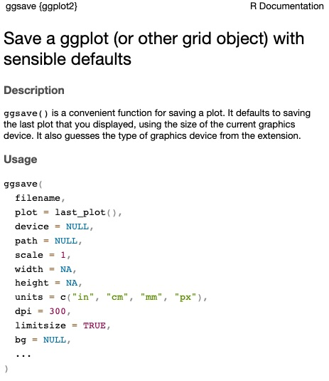

## Colors and color palettes | colorRampPalette

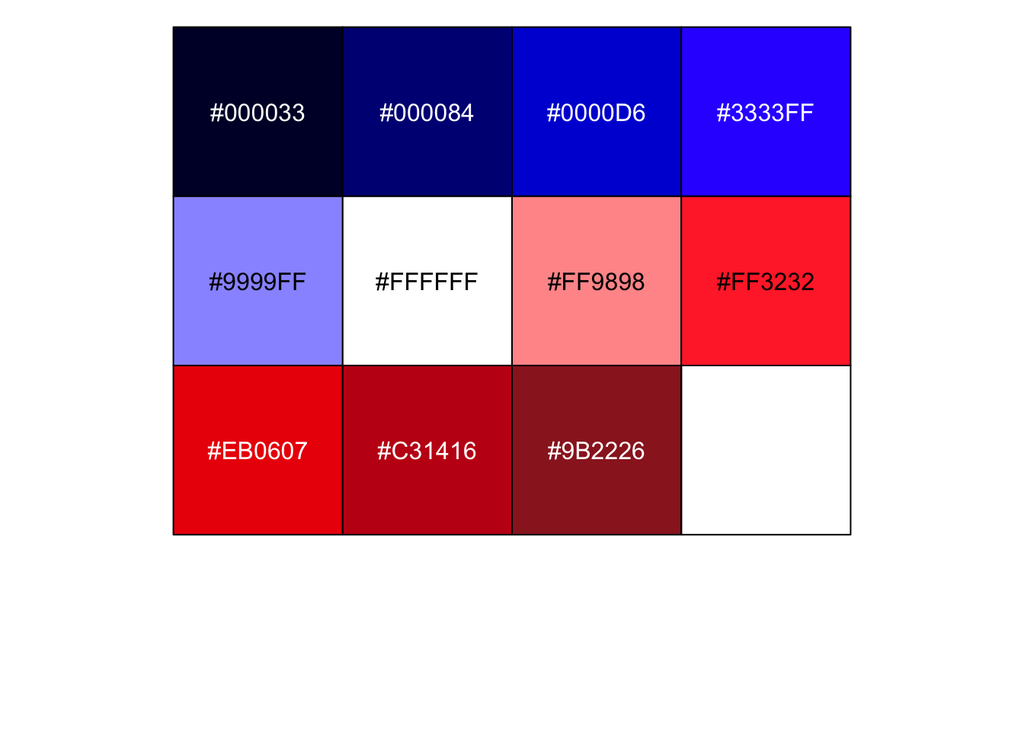

```r
pal = colorRampPalette(c("#000033", "blue", "#FFFFFF", "red", "#9B2226"))(11)
scales::show_col(pal)
```

## Colors and color palettes | viridis and viridisLite

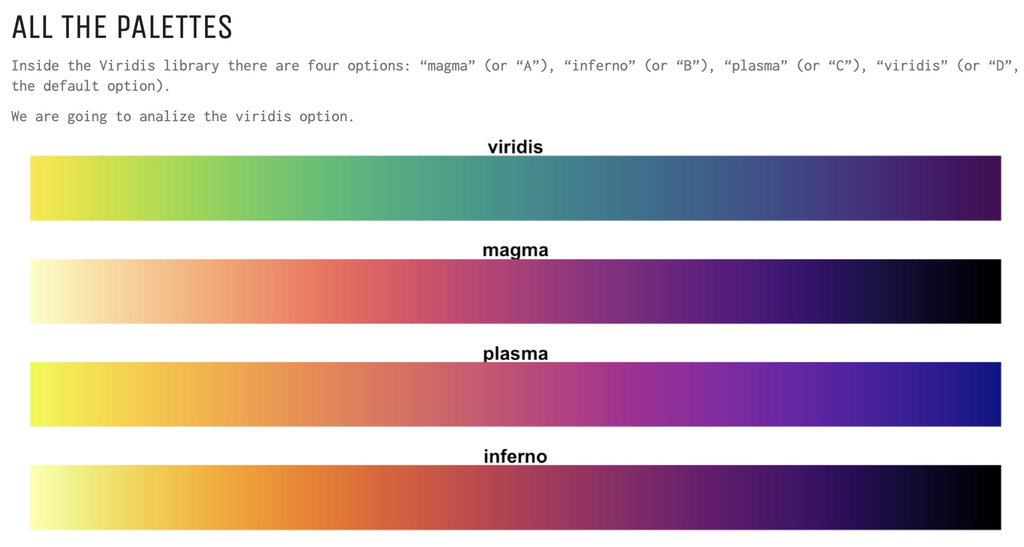

Image from https://www.thinkingondata.com/something-about-viridis-library/

## Colors and color palettes

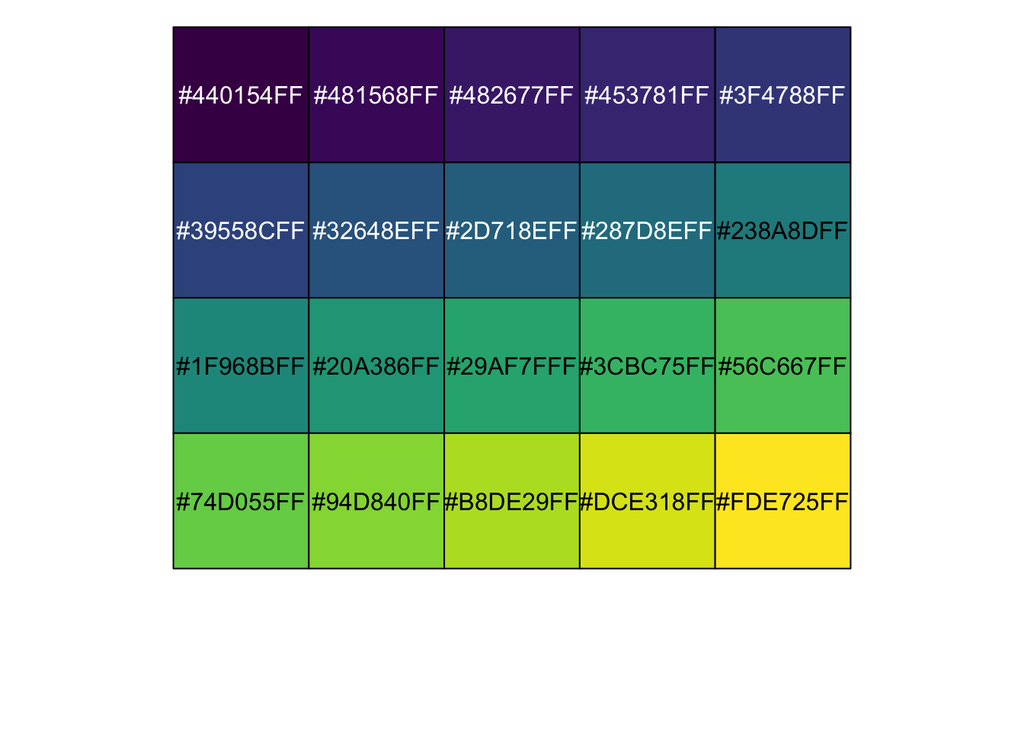

```r
pal2 = viridis(20)
show_col(pal2)
```

## Colors and color palettesList from https://www.skillshare.com/en/blog/7-best-color-palette-generators-to-try/

- Canva Color Palette Generator https://www.canva.com/colors/color-palette-generator/
- Adobe Color Wheel https://color.adobe.com/create/color-wheel
- Muzli Color Palette Generator https://colors.muz.li/
- Colormind http://colormind.io/
- CSS Drive Color Palette Generator http://www.cssdrive.com/imagepalette/
- Coolors https://coolors.co/
- BrandColors http://brandcolors.net/
- MoMAColors https://github.com/BlakeRMills/MoMAColors

## Manual colors in plots

- scale_color_[many options]
- scale_fill_[many options]

## Visualization function

What are the different parts?

- Data wrangling - factoring parameters of interest
- Mapping aesthetics
- Variables for fill and color
- List of comparisons for stats
- Heights for stats bars
- List of values for colors
- Name changes - what delimeter are we using

## Revisiting our basic ggplot figure build | Let’s write a function that makes this visualization for us

```r
iris |>
  mutate(Species = factor(Species, levels = c("setosa", "versicolor", "virginica"),
                          labels = c("Setosa", "Versicolor", "Virginica"))) |>
  ggplot(aes(x = Species, y = Sepal.Length)) +
  geom_violin(aes(color = Species), trim = FALSE, show.legend = FALSE) +
  geom_jitter(aes(fill = Petal.Length), shape = 21, size = 3, alpha = 0.8) +
  geom_signif(comparisons = list(c("Setosa", "Versicolor"),
                                 c("Versicolor", "Virginica"),
                                 c("Setosa", "Virginica")),
              map_signif_level = T,
              y_position = c(7.8, 8.5, 9),
              tip_length = 0) +
  scale_fill_viridis(name = "Petal length") +
  scale_color_manual(values = c("setosa" = "#06d6a0", "versicolor" = "#118ab2",
                                "virginica" = "#073b4c")) +
  ylab("Sepal length") +
  theme(axis.title = element_text(size = 12),
        axis.text.x = element_text(face = "italic"))
```

## Automate building the figure

- Clone https://github.com/mlwarren20/FunWithFunctionsAndPlots.git
- Create a branch for your function
- Create a directory that will contain your function and Readme
- Create a Readme for your function in your new directory
- Push the R code and Readme directory for your function